# Introduction to scRNA-seq - Part V: Pseudobulk and differential gene expression

Kerry Lynn Gendreau

28/04/2023

**This is part of the report, however you may skip the DESeq2 analysis**

*Questions to be answered in the protocol:*

- How do we calculate distances between annotated clusters?

First of all, as explained in previous parts, distances on the 2D UMAP plot are not meaningful. It is necessary to have another way to compare between the already obtained clusters. Here we calculate the average expression for each gene in each cluster and based on it we measured the Spearman correlation coefficient, in order to asses the degree of similarity between different cell types. The Spearman correlation coefficient is also calculated using the specificity indeces (average expression within cell-type normalized by total expresion). The later helps shifting the attention to genes that show cell type-specific patterns of expression. Both of those methods, with the later being more efficient, managed to separate the clusters into groups (neurons, non-neurons) which made biological sense.

- Why can we not use the distance on a UMAP plot for this?

UMAP is a non-linear dimensionality reduction method. As such it give emphasis to local distances than global and distances when constructing the graph. The distances between clusters on the 2D plot are likely to be meaningless.

- Why can the FindMarkers function introduce biases when calculating differentially expressed genes in a data set with multiple replicates?

In one dataset we may have information coming from multiple replicates which on its own is a source of variance. FindMarkers performs statistical tests for individual cells of the data set and does not retain the information of origin of the cells. Thus, it can introduce biases. If for example the samples come from different batches, it can introduce systematic differences in gene expression that are not related to the biological differences but are simply a result of batch effects.

Furthermore, methods that test cells individually can be biased for highly expressed genes, potentially leading to false positives. This bias arises because highly expressed genes tend to have higher variability in their expression levels and be counted as significantly variable by chance. Also, treating each cell as a sample often inflates the p-values (multiple hypothesis testing problem) introducing many false positives.

Additionally, sometimes we need to draw conclusions at the level of the population and not the individual, meaning we want to compare between different conditions and not between different cells under the same condition/ coming from the same individual.

- How can we calculate differential expression instead?

An alternative approach as shown bellow is using Pseudobulk analysis combined with DEseq2. After cells are grouped by cell-type/ conditions etc., the average expression for each gene in each group is calculated. Now gene expression can be calculated at the group level and not the cell levels (as with FindMarkers function). By pooling together the expression values from many cells the impact of technical noise, drop outs and highly expressed genes is reduced, always at the cost of intra-group heterogeneity. DESeq then is used to identify the genes which show significant difference in expression levels between different conditions or groups.

## Load packages and data

```r
library(Seurat)
library(dplyr)
library(tidyr)
library(DESeq2)
```

```r
library(ggplot2)
library(pheatmap)
library(stats)
library(ggdendro)

set.seed(42)
```

```r
rm(list = ls())
gc()
```

```
##            used  (Mb) gc trigger  (Mb) limit (Mb) max used  (Mb)
## Ncells  6952646 371.4   13524177 722.3         NA  8325933 444.7
## Vcells 12123930  92.5   17824054 136.0      16384 14786710 112.9
```

Read in the annotated Seurat object

```r
ple5 <- readRDS("srt_04_ple5v2.rds")
```

## Downsampling

We saw before that we have very different cluster sizes. We should downsample our larger clusters so all the clusters are closer in size. This allows for equal representation from each cluster, bias mitigation and is more efficient in terms of computational time.

```r
ple5.small <- subset(ple5, downsample = 40)
```

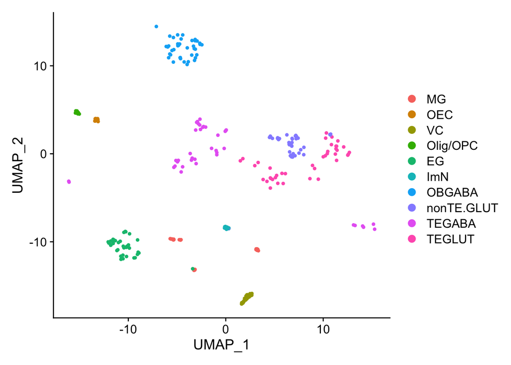

```r
DimPlot(ple5.small)
```

# Pseudobulk analysis

## Calculate average expression for each cell type in Seurat

```r
ple5_avg <- AverageExpression(object = ple5.small, return.seurat = TRUE)
```

## Extract the count matrix from the Seurat average expression object

Extract count matrix from average expression Seurat object as dataframe

```r
ple5_avg_mtx <- as.data.frame(ple5_avg@assays[["RNA"]]@counts)
```

```r
head(ple5_avg_mtx)
```

```
##                  MG       OEC         VC  Olig/OPC        EG        ImN
## LGI3     0.00000000 0.0000000 0.11590717 2.7127756 3.1163651 0.12982408
## ENTPD7   0.10602750 0.3222946 0.23383649 0.4077527 0.5714487 0.35808453
## KIAA1644 0.00000000 0.0000000 0.10835794 0.8098682 0.9495203 0.10753577
## PI4KB    0.21268070 0.4512166 0.03395355 0.6357870 0.4523903 0.25417958
## NUAK2    0.01908106 0.1995161 0.00000000 0.1239719 0.7129503 0.06343118
## CYLD     0.15976357 0.2558515 0.14583289 0.2665028 0.2741086 0.79800077
##             OBGABA nonTE.GLUT    TEGABA     TEGLUT
## LGI3     0.2886428  0.2843610 0.2838043 0.05434043
## ENTPD7   0.2777044  0.3476522 0.3177545 0.67762436
## KIAA1644 1.5858574  0.6561665 0.6752749 0.65218679
## PI4KB    0.3867382  0.4987488 0.2337695 0.24379055
## NUAK2    0.8350147  0.3929554 0.2218643 0.49241857
## CYLD     1.0428641  0.5969124 0.9601609 0.38091643
```

We now have a pseudobulk count table. In this table we see the average expression of each gene in each cluster. This reduces cell-to-cell variability and provides a simplified summary of the information making it easier to compare patterns across cell types. On the downside we lose information about the heterogeneity of the cell groups.

## Calculate correlation

Now we’ll calculate correlation coefficients for average expression using Spearman correlation. Spearman correlation coefficient is calculated for the expression levels of genes across the clusters, in order to asses the degree of similarity between different cell types.

```r
matrix_cor_avg <- cor(as.matrix(ple5_avg_mtx), method = "spearman")
```

```r
head(matrix_cor_avg)
```

```
##                 MG       OEC        VC  Olig/OPC        EG       ImN    OBGABA
## MG       1.0000000 0.6041115 0.5783603 0.5129178 0.5501534 0.4972476 0.5016324
## OEC      0.6041115 1.0000000 0.6771291 0.6588596 0.7305960 0.5672853 0.5715293
## VC       0.5783603 0.6771291 1.0000000 0.5715228 0.6447405 0.5178964 0.5165327
## Olig/OPC 0.5129178 0.6588596 0.5715228 1.0000000 0.7351469 0.7858126 0.7885401
## EG       0.5501534 0.7305960 0.6447405 0.7351469 1.0000000 0.6190033 0.6246681
## ImN      0.4972476 0.5672853 0.5178964 0.7858126 0.6190033 1.0000000 0.8464471
##          nonTE.GLUT    TEGABA    TEGLUT
## MG        0.4942602 0.4787235 0.4937873
## OEC       0.5678931 0.5649541 0.5606590
## VC        0.5181348 0.5154811 0.5205970
## Olig/OPC  0.8119655 0.8146529 0.7974327
## EG        0.6353212 0.6332793 0.6263869
## ImN       0.8960171 0.8819738 0.8704462
```

The closer the values are to 1, the more similar the groups are.

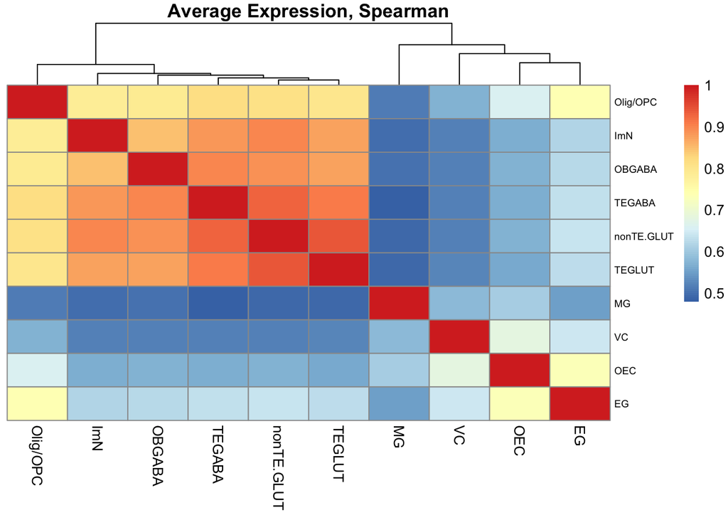

```r
heatmap <- pheatmap(matrix_cor_avg,
         main = "Average Expression, Spearman",
         cluster_cols = TRUE,
         cluster_rows = TRUE,
         scale = 'none',
         treeheight_row = 0,
         treeheight_col = 40,
         fontsize_row = 7,
         display_numbers = FALSE)
```

We see that the cells are divided into two main categories. With the exception of oligodendrocytes, supporting cells (microglia, vascular cells, olfactory ensheathing cells and ependymoglia) on one side and the Neurons on the other side. This split is also a confirmation of the validity of the data and our analytical process.

GABAergic and Glutamatergic clusters are not well separated.

```r
cluster.tree.avg <- hclust(as.dist(1-matrix_cor_avg))
```

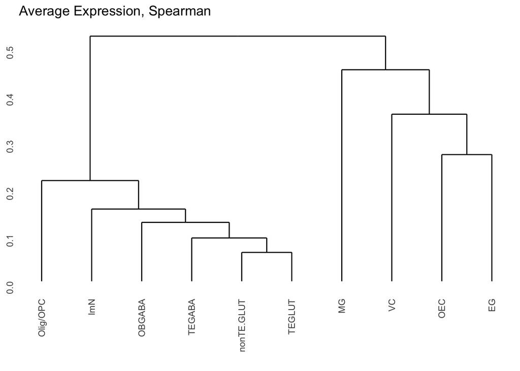

```r
ggdendrogram(cluster.tree.avg) + ggtitle("Average Expression, Spearman")
```

The scale on the y-axis of the dendrogram represents the dissimilarity or distance between clusters, and the height of the branches represents the level of dissimilarity. Here the Spearman correlation coefficient was subtracted from 1. This transformation ensures that higher correlation values correspond to smaller dissimilarity values.

The neurons are much closer to one another than the non-neurons.

Why might this be?

Generally, neurons could to be closer to each other developmentaly and evolutionarily. Or they could possibly be more conserved. Another possibility is that it is being driven by a few highly expressed genes. Our analysis after all is based on the similarities of average gene expression between the clusters.

This also means that the signals from genes with lower expression levels that are differentially expressed (e.g., transcription factors) may be lost when focusing on average expression.

It is important to be certain that our cells are clustered based on biological features and not technical artefacts. For example genes could be clustered based on differences in UMI number, which could be caused by cell doublets or PCR fluctuations.

A nice way to check this is plotting the counts for the cells of each cluster as a box plot.

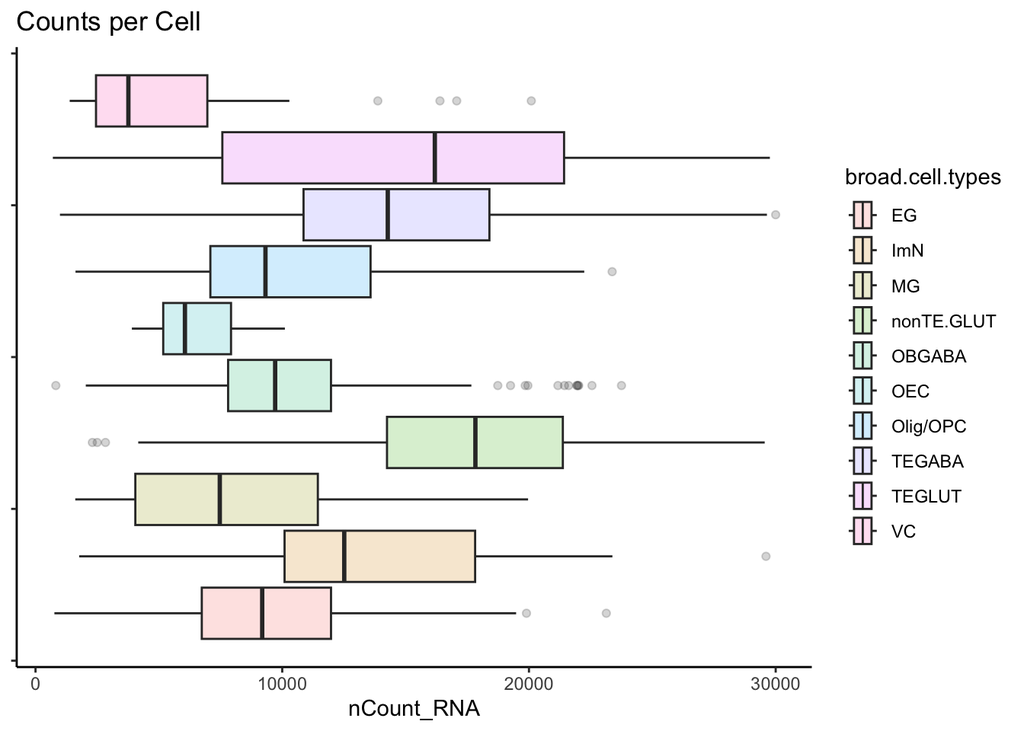

```r
 ple5@meta.data %>%
    ggplot(aes(x=nCount_RNA, fill= broad.cell.types)) +
    geom_boxplot(alpha = 0.2) +
    theme_classic() +
    theme(axis.text.y = element_blank()) +
    ggtitle("Counts per Cell")
```

Vascular Cells have the lowest counts. Neurons have generally high counts.

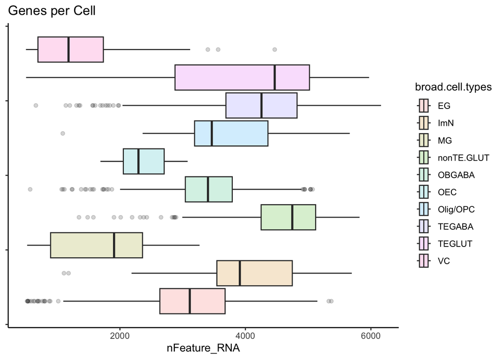

```r
 ple5@meta.data %>%
    ggplot(aes(x=nFeature_RNA, fill= broad.cell.types)) +
    geom_boxplot(alpha = 0.2) +
    theme_classic() +
    theme(axis.text.y = element_blank()) +
    ggtitle("Genes per Cell")
```

There is a difference between cell count and genes per cell among our clusters. This makes sense as they are two different things. Nevertheless, the patter is the same and they have a positive correlation. Clusters whose cells have more counts, also have more features. This could have a biological underlying explanation (e.g. generally elevated trascriptional activity which helps capturing more features), or could be a technical artifact where stochastic fluctuations during PCR amplification and sequencing lead to more UMI reads in some droplets and as a consequence more unique features are captured.

## Calculate specificity index.

One way we can get around some of these issues with the average expression levels is to use specificity indeces.

The specificity index is the average expression of a gene within one cell type compared to the average expression of the gene across all cell types.

First we’ll create a new column containing the gene names

```r
ple5_spec <- dplyr::mutate(ple5_avg_mtx, "gene" = rownames(ple5_avg_mtx))
```

```r
head(ple5_spec)
```

```
##                  MG       OEC         VC  Olig/OPC        EG        ImN
## LGI3     0.00000000 0.0000000 0.11590717 2.7127756 3.1163651 0.12982408
## ENTPD7   0.10602750 0.3222946 0.23383649 0.4077527 0.5714487 0.35808453
## KIAA1644 0.00000000 0.0000000 0.10835794 0.8098682 0.9495203 0.10753577
## PI4KB    0.21268070 0.4512166 0.03395355 0.6357870 0.4523903 0.25417958
## NUAK2    0.01908106 0.1995161 0.00000000 0.1239719 0.7129503 0.06343118
## CYLD     0.15976357 0.2558515 0.14583289 0.2665028 0.2741086 0.79800077
##             OBGABA nonTE.GLUT    TEGABA     TEGLUT     gene
## LGI3     0.2886428  0.2843610 0.2838043 0.05434043     LGI3
## ENTPD7   0.2777044  0.3476522 0.3177545 0.67762436   ENTPD7
## KIAA1644 1.5858574  0.6561665 0.6752749 0.65218679 KIAA1644
## PI4KB    0.3867382  0.4987488 0.2337695 0.24379055    PI4KB
## NUAK2    0.8350147  0.3929554 0.2218643 0.49241857    NUAK2
## CYLD     1.0428641  0.5969124 0.9601609 0.38091643     CYLD
```

Now we want to rearrange the data using the gather() function from the tidyr package so that is in long format. This mean that we group all of the columns (cell types) together in one column. We’ll have multiple rows for each gene.

```r
ple5_spec <-  tidyr::gather(ple5_spec, key = "cell.type",
                            value = "avg_expr", -gene)
```

```r
head(ple5_spec)
```

```
##       gene cell.type   avg_expr
## 1     LGI3        MG 0.00000000
## 2   ENTPD7        MG 0.10602750
## 3 KIAA1644        MG 0.00000000
## 4    PI4KB        MG 0.21268070
## 5    NUAK2        MG 0.01908106
## 6     CYLD        MG 0.15976357
```

Then we’ll group the dataframe by gene

```r
ple5_spec <- ple5_spec %>%
  group_by(gene)
```

Then we’ll only keep the genes which have an average expression more than 0

```r
ple5_spec <- dplyr::filter(ple5_spec, sum(avg_expr) > 0)
```

Then we’ll add a new column to the the dataframe that equals the mean average expression across all clusters for each gene

```r
ple5_spec <- dplyr::mutate(ple5_spec, avg_tot = mean(avg_expr))
```

Then ungroup the dataframe.

```r
ple5_spec <- ungroup(ple5_spec)
```

```r
head(ple5_spec)
```

```
## # A tibble: 6 × 4
##   gene     cell.type avg_expr avg_tot
##   <chr>    <chr>        <dbl>   <dbl>
## 1 LGI3     MG          0        0.699
## 2 ENTPD7   MG          0.106    0.362
## 3 KIAA1644 MG          0        0.554
## 4 PI4KB    MG          0.213    0.340
## 5 NUAK2    MG          0.0191   0.306
## 6 CYLD     MG          0.160    0.488
```

Now we’ll calculate the specificity index by dividing the average expression within each cluster by the average expression across all clusters.

```r
ple5_spec <- dplyr::mutate(ple5_spec, spec_index = avg_expr / avg_tot)
```

```r
head(ple5_spec)
```

```
## # A tibble: 6 × 5
##   gene     cell.type avg_expr avg_tot spec_index
##   <chr>    <chr>        <dbl>   <dbl>      <dbl>
## 1 LGI3     MG          0        0.699     0
## 2 ENTPD7   MG          0.106    0.362     0.293
## 3 KIAA1644 MG          0        0.554     0
## 4 PI4KB    MG          0.213    0.340     0.625
## 5 NUAK2    MG          0.0191   0.306     0.0623
## 6 CYLD     MG          0.160    0.488     0.327
```

Then we’ll subset the dataframe and only leave the columns for cell type, gene, and specificity index

```r
ple5_spec_final <- dplyr::select(ple5_spec, -avg_expr, -avg_tot)
```

```r
head(ple5_spec_final)
```

```
## # A tibble: 6 × 3
##   gene     cell.type spec_index
##   <chr>    <chr>          <dbl>
## 1 LGI3     MG            0
## 2 ENTPD7   MG            0.293
## 3 KIAA1644 MG            0
## 4 PI4KB    MG            0.625
## 5 NUAK2    MG            0.0623
## 6 CYLD     MG            0.327
```

Then we’ll convert the dataframe back to wide format using the spread() function from tidyr.

```r
ple5_spec_final <- tidyr::spread(ple5_spec_final,
                                 cell.type, spec_index, fill = 0)
```

```r
head(ple5_spec_final)
```

```
## # A tibble: 6 × 11
##   gene       EG   ImN    MG nonTE.GLUT OBGABA    OEC `Olig/OPC` TEGABA TEGLUT
##   <chr>   <dbl> <dbl> <dbl>      <dbl>  <dbl>  <dbl>      <dbl>  <dbl>  <dbl>
## 1 26-29-p 1.98  1.50  2.44       0.447  0.439 0.690       1.58   0.444  0.456
## 2 44256   0.127 1.21  0.708      1.93   1.63  0.0655      0.590  0.886  2.85
## 3 44257   1.46  0.676 0.173      0.994  0.693 2.54        0.517  0.841  0.837
## 4 44258   6.70  0     0          0.817  0.870 0           0      1.04   0.566
## 5 44260   1.50  0.762 0.374      1.61   1.29  0.803       1.32   1.27   0.888
## 6 44261   1.81  1.58  0.520      1.21   0.931 0.851       0.841  1.11   1.04
## # ℹ 1 more variable: VC <dbl>
```

The tidyr package converted our dataframe to another, similar format (a tibble). Now we’ll convert it back to a dataframe.

```r
ple5_spec_final <- as.data.frame(ple5_spec_final)
```

Then we’ll reassign the rownames to the dataframe

```r
rownames(ple5_spec_final) <- ple5_spec_final$gene
```

```r
head(ple5_spec_final)
```

```
##            gene        EG       ImN        MG nonTE.GLUT    OBGABA        OEC
## 26-29-p 26-29-p 1.9848074 1.4965411 2.4355574  0.4472190 0.4394534 0.69018603
## 44256     44256 0.1268165 1.2101203 0.7077159  1.9285349 1.6333994 0.06547865
## 44257     44257 1.4595534 0.6763460 0.1733030  0.9939643 0.6930422 2.54183268
## 44258     44258 6.7028439 0.0000000 0.0000000  0.8171808 0.8700847 0.00000000
## 44260     44260 1.4955220 0.7623286 0.3737361  1.6123198 1.2864397 0.80341666
## 44261     44261 1.8050296 1.5755636 0.5200743  1.2141406 0.9311937 0.85091516
##          Olig/OPC    TEGABA    TEGLUT         VC
## 26-29-p 1.5826696 0.4444647 0.4561594 0.02294187
## 44256   0.5898349 0.8858982 2.8522013 0.00000000
## 44257   0.5168226 0.8406539 0.8373699 1.26711204
## 44258   0.0000000 1.0443425 0.5655481 0.00000000
## 44260   1.3196750 1.2731506 0.8883340 0.18507751
## 44261   0.8410364 1.1058467 1.0354379 0.12076203
```

And we’ll remove the column for gene

```r
ple5_spec_final <- ple5_spec_final[, -1]
```

```r
head(ple5_spec_final)
```

```
##                EG       ImN        MG nonTE.GLUT    OBGABA        OEC  Olig/OPC
## 26-29-p 1.9848074 1.4965411 2.4355574  0.4472190 0.4394534 0.69018603 1.5826696
## 44256   0.1268165 1.2101203 0.7077159  1.9285349 1.6333994 0.06547865 0.5898349
## 44257   1.4595534 0.6763460 0.1733030  0.9939643 0.6930422 2.54183268 0.5168226
## 44258   6.7028439 0.0000000 0.0000000  0.8171808 0.8700847 0.00000000 0.0000000
## 44260   1.4955220 0.7623286 0.3737361  1.6123198 1.2864397 0.80341666 1.3196750
## 44261   1.8050296 1.5755636 0.5200743  1.2141406 0.9311937 0.85091516 0.8410364
##            TEGABA    TEGLUT         VC
## 26-29-p 0.4444647 0.4561594 0.02294187
## 44256   0.8858982 2.8522013 0.00000000
## 44257   0.8406539 0.8373699 1.26711204
## 44258   1.0443425 0.5655481 0.00000000
## 44260   1.2731506 0.8883340 0.18507751
## 44261   1.1058467 1.0354379 0.12076203
```

Then we’ll make a correlation matrix from the specificity indeces.

```r
matrix_cor_spec <- cor(as.matrix(ple5_spec_final), method = "spearman")
```

```r
matrix_cor_spec[1:5,1:5]
```

```
##                     EG         ImN          MG nonTE.GLUT      OBGABA
## EG          1.00000000 -0.14131065  0.06194083 -0.2129225 -0.14537748
## ImN        -0.14131065  1.00000000 -0.02740686  0.3976200  0.34112307
## MG          0.06194083 -0.02740686  1.00000000 -0.1237783 -0.01734278
## nonTE.GLUT -0.21292255  0.39761998 -0.12377832  1.0000000  0.37833985
## OBGABA     -0.14537748  0.34112307 -0.01734278  0.3783398  1.00000000
```

We now also have negative values, as some genes have higher levels than the average and some have lower.

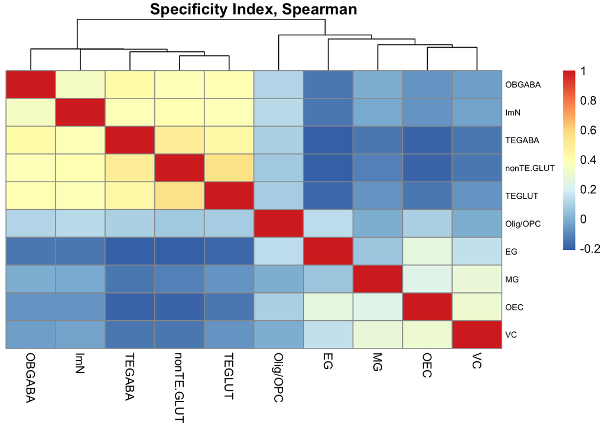

```r
heatmap <- pheatmap(matrix_cor_spec,
         main = "Specificity Index, Spearman",
         cluster_cols = TRUE,
         cluster_rows = TRUE,
         scale = 'none',
         treeheight_row = 0,
         treeheight_col = 40,
         fontsize_row = 7,
         display_numbers = FALSE)
```

Now all supporting cells (oligodendrocytes, microglia, vascular cells, olfactory ensheathing cells and ependymoglia) are on one side and the Neurons on the other side.

```r
cluster.tree.spec <- hclust(as.dist(1-matrix_cor_spec))
```

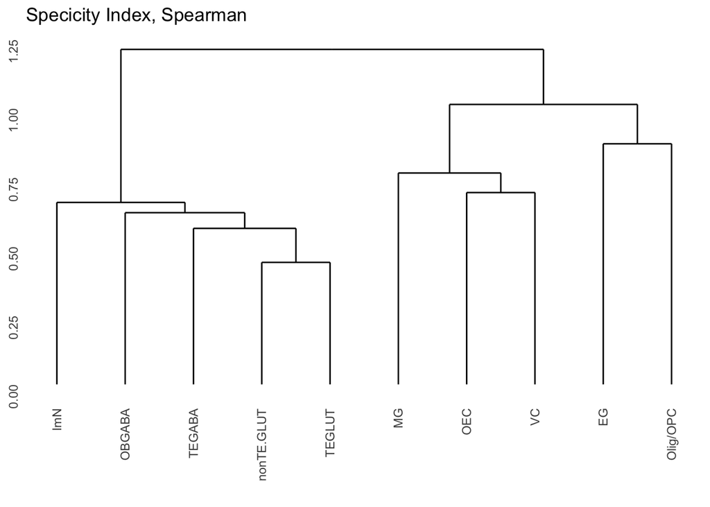

```r
ggdendrogram(cluster.tree.spec) + ggtitle("Specicity Index, Spearman")
```

We can use additional packages (e.g., pvclust()) to calculate statistics such as bootstrap values that tell us about our confidence in the cluster assignments.

# Differential expression analysis with DESeq2

We already showed one way to calculate differentially expressed genes using Wilcoxon tests (with the FindMarkers() function from Seurat). However, some assumptions of this test are violated with single cell data and it is biased toward highly expressed genes.

We can use our pseudobulk data as an input for more robust algorithms to detect differential expression in RNAseq data, such as DESeq2, edgeR, or limma.

We will use the raw counts matrix from the average expression matrix to assess differential gene expression.

Let’s clear the environment and start anew so we don’t have to worry about accidentally calling on some variable that already has an identity.

```r
rm(list = ls())
gc()
```

```
##            used  (Mb) gc trigger  (Mb) limit (Mb) max used  (Mb)
## Ncells  7295630 389.7   13524177 722.3         NA 13524177 722.3
## Vcells 12827312  97.9   57042753 435.3      16384 59352852 452.9
```

```r
ple5 <- readRDS("srt_04_ple5v2.rds")
```

DEseq2 requires a count matrix as well as a dataframe that describes the relevant metadata for the analysis.

```r
ple5_avg <- AverageExpression(object = ple5, return.seurat = TRUE)
counts <- as.matrix(ple5_avg@assays[["RNA"]]@counts)
```

```r
counts[1:5,1:5]
```

```
##                  MG       OEC         VC  Olig/OPC        EG
## LGI3     0.00000000 0.0000000 0.10369839 2.7127756 2.6721173
## ENTPD7   0.12155881 0.3222946 0.24056384 0.4077527 0.4252142
## KIAA1644 0.00000000 0.0000000 0.12394027 0.8098682 0.6124769
## PI4KB    0.45485941 0.4512166 0.07087232 0.6357870 0.5513121
## NUAK2    0.05210308 0.1995161 0.00000000 0.1239719 0.5592353
```

The counts need to be integers in order for DESeq2 to process them. We’ll therefore round the average counts.

```r
counts <- round(counts)
```

```r
counts[1:5,1:10]
```

```
##          MG OEC VC Olig/OPC EG ImN OBGABA nonTE.GLUT TEGABA TEGLUT
## LGI3      0   0  0        3  3   0      0          0      0      0
## ENTPD7    0   0  0        0  0   0      0          0      0      0
## KIAA1644  0   0  0        1  1   0      1          1      1      1
## PI4KB     0   0  0        1  1   0      0          0      0      0
## NUAK2     0   0  0        0  1   0      1          0      0      0
```

```r
neuron.counts <- counts[,7:10]
```

```r
head(neuron.counts)
```

```
##          OBGABA nonTE.GLUT TEGABA TEGLUT
## LGI3          0          0      0      0
## ENTPD7        0          0      0      0
## KIAA1644      1          1      1      1
## PI4KB         0          0      0      0
## NUAK2         1          0      0      0
## CYLD          1          1      1      0
```

Now we’ll make the metadata dataframe.

```r
coldata <- data.frame("cell.type" = colnames(neuron.counts),
                      "broad.cell.type" = c("GABA","GABA","GLUT","GLUT"))
```

```r
rownames(coldata) <- coldata$cell.type
```

```r
head(coldata)
```

```
##             cell.type broad.cell.type
## OBGABA         OBGABA            GABA
## nonTE.GLUT nonTE.GLUT            GABA
## TEGABA         TEGABA            GLUT
## TEGLUT         TEGLUT            GLUT
```

We need the row names in the metadata to match the column names in the counts matrix and they must be in the same order. So the code below should be TRUE.

```r
all(rownames(coldata) == colnames(neuron.counts))
```

```
## [1] TRUE
```

Now we’ll create a DESeq object.

```r
dds <- DESeqDataSetFromMatrix(countData = neuron.counts, colData = coldata,
                              design = ~ broad.cell.type)
```

Then we’ll check to see what the object looks like.

```r
dds
```

```
## class: DESeqDataSet
## dim: 13103 4
## metadata(1): version
## assays(1): counts
## rownames(13103): LGI3 ENTPD7 ... FAM83C opsX
## rowData names(0):
## colnames(4): OBGABA nonTE.GLUT TEGABA TEGLUT
## colData names(2): cell.type broad.cell.type
```

13103 genes 4 clusters

Then we’ll run DESeq.

```r
dds <- DESeq(dds)
```

```
## -- note: fitType='parametric', but the dispersion trend was not well captured by the
##    function: y = a/x + b, and a local regression fit was automatically substituted.
##    specify fitType='local' or 'mean' to avoid this message next time.
```

Let’s store the results of the DESeq analysis and have a look at them.

```r
res <- results(dds)
```

```r
summary(res)
```

```
##
## out of 4520 with nonzero total read count
## adjusted p-value < 0.1
## LFC > 0 (up)       : 0, 0%
## LFC < 0 (down)     : 0, 0%
## outliers [1]       : 0, 0%
## low counts [2]     : 0, 0%
## (mean count < 0)
## [1] see 'cooksCutoff' argument of ?results
## [2] see 'independentFiltering' argument of ?results
```

Now let’s store the results as a dataframe.

```r
res.df <- as.data.frame(results(dds))
```

```r
head(res.df)
```

```
##          baseMean log2FoldChange    lfcSE          stat    pvalue padj
## LGI3         0.00             NA       NA            NA        NA   NA
## ENTPD7       0.00             NA       NA            NA        NA   NA
## KIAA1644     1.00   2.322922e-15 3.154878  7.362955e-16 1.0000000    1
## PI4KB        0.00             NA       NA            NA        NA   NA
## NUAK2        0.25  -1.442671e+00 4.997486 -2.886794e-01 0.7728267    1
## CYLD         0.75  -9.999842e-01 3.974302 -2.516125e-01 0.8013406    1
```

baseMean is the average of the normalized counts for a gene across all samples.

We see many high p-values. Sort by p-value

```r
res.df <- dplyr::arrange(res.df, pvalue)
```

```r
head(res.df)
```

```
##        baseMean log2FoldChange    lfcSE      stat     pvalue padj
## CPNE6      4.75      -3.087449 1.811343 -1.704508 0.08828613    1
## TAC1       2.25       4.612574 2.746389  1.679505 0.09305363    1
## LPIN2      5.25      -2.584952 1.686758 -1.532497 0.12539993    1
## UNC13B     3.00      -3.459408 2.360730 -1.465397 0.14281251    1
## CHGA      10.75       1.540568 1.062100  1.450493 0.14692108    1
## RPRML      5.00      -1.999994 1.380591 -1.448651 0.14743513    1
```

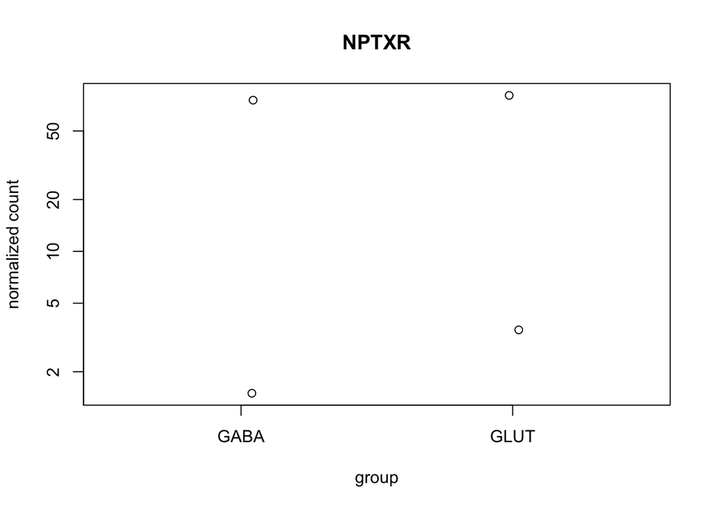

```r
plotCounts(dds, gene="NPTXR", intgroup="broad.cell.type")
```

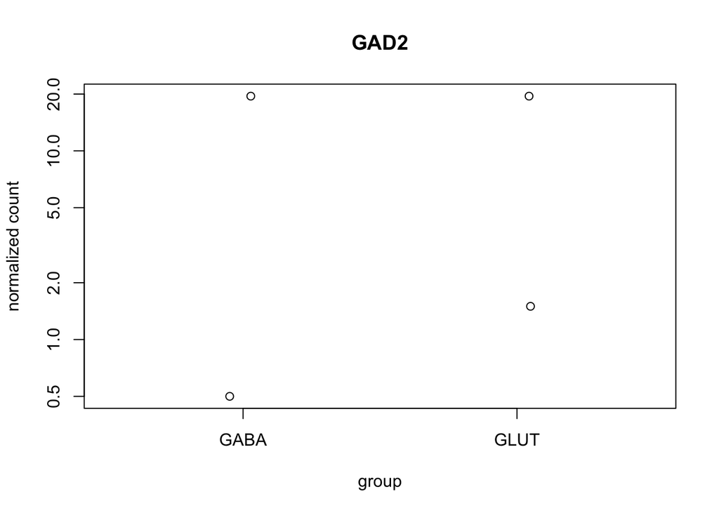

```r
plotCounts(dds, gene="GAD2", intgroup="broad.cell.type")
```

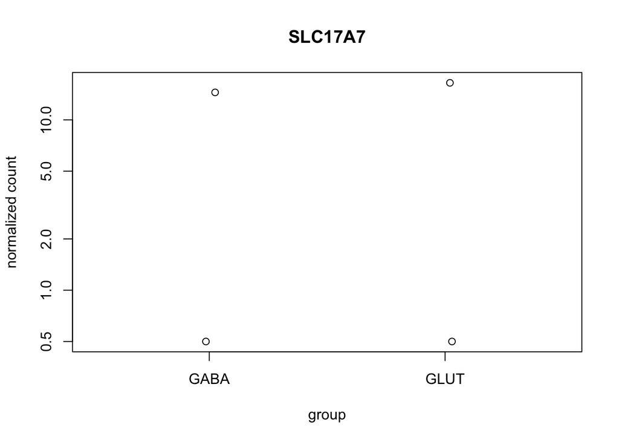

```r
plotCounts(dds, gene="SLC17A7", intgroup="broad.cell.type")
```

We can also look at the count data as a heatmap. Let’s look at the top 20 differentially expressed genes.

```r
top20 <- rownames(res.df)[1:20]
```

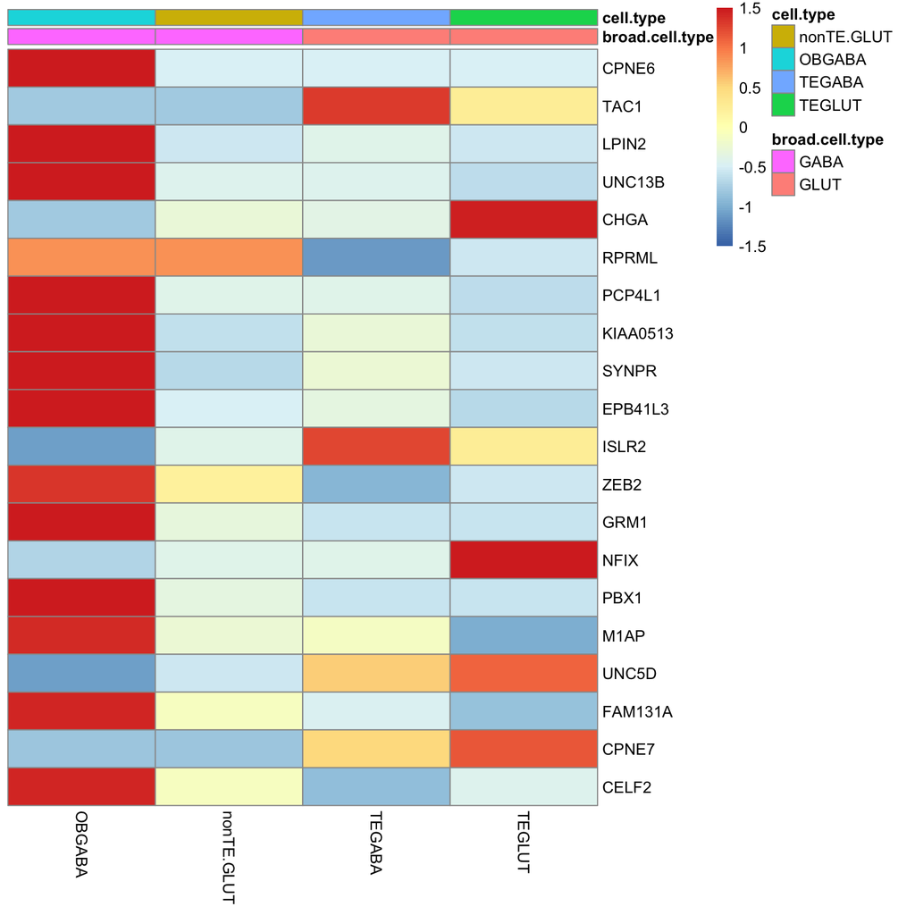

```r
df <- as.data.frame(colData(dds)[,c("broad.cell.type", "cell.type")])

pheatmap(assay(dds)[top20,], cluster_rows=FALSE, show_rownames=TRUE,
         cluster_cols = FALSE, annotation_col=df, scale= "row")
```

We don’t see so many significant differences here, but this is likely because this tool is designed to statistically compare replicates.

If we were to integrate samples from the same brain region from different animals, we could design a better test for differential expression.

DESeq2 can also be used to compare different kinds of datasets with more complex experimental designs.

e.g., treated versus untreated in males versus females